# Energy Consumption in Europe

Aidan Boland

10 Aug 2020

### Load Necessary Libraries

```r
library(tidyverse)
library(ggplot2)
library(scales)

library(knitr)
library(kableExtra)
```

### Reading in Data

We first of all read in the data using `readr::read_csv`.

```r
# Read in data
energy_types <- readr::read_csv('https://raw.githubusercontent.com/rfordatascience/tidytuesday/master/data/2020/2020-08-04/energy_types.csv')
```

```r
energy_types %>%
  head() %>% # Looks at the first 6 entries
  kable() %>% # Only needed for markdown docs to make table look nice
  kable_styling() # Extra parameters for making nice tables in markdown
```

| country | country_name | type | level | 2016 | 2017 | 2018 |
| --- | --- | --- | --- | --- | --- | --- |
| BE | Belgium | Conventional thermal | Level 1 | 30728 | 31316.0 | 30092.635 |
| BE | Belgium | Nuclear | Level 1 | 41430 | 40128.5 | 26995.628 |
| BE | Belgium | Hydro | Level 1 | 1476 | 1360.9 | 1239.248 |
| BE | Belgium | Pumped hydro power | Level 2 | 1110 | 1093.2 | 983.190 |
| BE | Belgium | Wind | Level 1 | 5340 | 6387.9 | 7177.346 |
| BE | Belgium | Solar | Level 1 | 3070 | 3264.3 | 3488.979 |

## Caclulating Percentage of Renewable

### Initial Data Tidy

There is one country_name which is unpopulated. The country code reveals this to be the United Kingdom.

```r
energy_types %>%
  filter(is.na(country_name)) %>%
  head() %>% kable() %>% kable_styling()
```

| country | country_name | type | level | 2016 | 2017 | 2018 |
| --- | --- | --- | --- | --- | --- | --- |
| UK | NA | Conventional thermal | Level 1 | 203165.19 | 189296.53 | 180837.905 |
| UK | NA | Nuclear | Level 1 | 65149.08 | 63886.86 | 59097.753 |
| UK | NA | Hydro | Level 1 | 8286.51 | 8723.43 | 7678.659 |
| UK | NA | Pumped hydro power | Level 2 | 2948.89 | 2862.01 | 2515.998 |
| UK | NA | Wind | Level 1 | 37262.70 | 50003.65 | 56903.961 |
| UK | NA | Solar | Level 1 | 10410.95 | 11524.87 | 12857.349 |

We can use the `mutate` function to firstly change the NA values in the ‘country_name’ column to United Kingdom, and secondly add a new variable which determines which entries are renewable or non renewable.

```r
renewable_percentages <-
  energy_types %>%
  mutate(
    # First tidy up country names and add a new variable to determine renewable
    country_name = case_when(
      is.na(country_name) == TRUE ~ "United Kingdom",
      TRUE ~ country_name
    ),
    # Then add an extra column with a flag for renewable
    renewable = case_when(
      type == "Conventional thermal" ~ "non_renewable",
      type == "Nuclear" ~ "non_renewable",
      T ~ "renewable"))

renewable_percentages %>% head() %>% kable() %>% kable_styling()
```

| country | country_name | type | level | 2016 | 2017 | 2018 | renewable |
| --- | --- | --- | --- | --- | --- | --- | --- |
| BE | Belgium | Conventional thermal | Level 1 | 30728 | 31316.0 | 30092.635 | non_renewable |
| BE | Belgium | Nuclear | Level 1 | 41430 | 40128.5 | 26995.628 | non_renewable |
| BE | Belgium | Hydro | Level 1 | 1476 | 1360.9 | 1239.248 | renewable |
| BE | Belgium | Pumped hydro power | Level 2 | 1110 | 1093.2 | 983.190 | renewable |
| BE | Belgium | Wind | Level 1 | 5340 | 6387.9 | 7177.346 | renewable |
| BE | Belgium | Solar | Level 1 | 3070 | 3264.3 | 3488.979 | renewable |

### Caclulate Totals

Using `group_by` and `summarise` we can calculate the yearly totals for renewable and non renewable for each country

```r
renewable_percentages <-
  renewable_percentages %>%
  # Group by country and energy type
  group_by(country_name, renewable) %>%
  # Now calculate the totals for each year
  summarise(`2016` = sum(`2016`), `2017` = sum(`2017`), `2018` = sum(`2018`))


renewable_percentages %>% head() %>% kable() %>% kable_styling()
```

| country_name | renewable | 2016 | 2017 | 2018 |
| --- | --- | --- | --- | --- |
| Albania | non_renewable | 0.00 | 0.000 | 0.000 |
| Albania | renewable | 7136.00 | 4497.807 | 8596.537 |
| Austria | non_renewable | 18065.01 | 20135.846 | 16350.754 |
| Austria | renewable | 49679.72 | 51238.167 | 62634.622 |
| Belgium | non_renewable | 72158.00 | 71444.500 | 57088.263 |
| Belgium | renewable | 11472.00 | 12597.200 | 13107.272 |

### Pivoting the Data

Our data has a separate column for each year and a single column for whether the data is renewable. To calculate percentages for each year we need to restructure the data. We do this in 2 steps.

First, we group the power totals into a single column and add a new column which denotes the year.

```r
renewable_percentages <-
  renewable_percentages %>%
  # Transform the data so that totals are in a single column
  pivot_longer(cols = c(`2016`, `2017`, `2018`),
               names_to = "year",
               values_to = "totals")

renewable_percentages %>% head() %>% kable() %>% kable_styling()
```

| country_name | renewable | year | totals |
| --- | --- | --- | --- |
| Albania | non_renewable | 2016 | 0.000 |
| Albania | non_renewable | 2017 | 0.000 |
| Albania | non_renewable | 2018 | 0.000 |
| Albania | renewable | 2016 | 7136.000 |
| Albania | renewable | 2017 | 4497.807 |
| Albania | renewable | 2018 | 8596.537 |

Secondly, we split the power totals into 2 columns, one column for renewable and one columns for non renewable.

```r
renewable_percentages <-
  renewable_percentages %>%
  # Transform data so that renewable and non renewable totals are in separate cols
  pivot_wider(names_from = renewable, values_from = totals)

renewable_percentages %>% head() %>% kable() %>% kable_styling()
```

| country_name | year | non_renewable | renewable |
| --- | --- | --- | --- |
| Albania | 2016 | 0.00 | 7136.000 |
| Albania | 2017 | 0.00 | 4497.807 |
| Albania | 2018 | 0.00 | 8596.537 |
| Austria | 2016 | 18065.01 | 49679.721 |
| Austria | 2017 | 20135.85 | 51238.167 |
| Austria | 2018 | 16350.75 | 62634.622 |

It is now straight forward to calculate the yearly percentage of renewable energy.

```r
renewable_percentages <-
  renewable_percentages %>%
  # Calculate percentage using cols from above
  mutate(green_percentage = renewable/(renewable + non_renewable))


renewable_percentages %>% head() %>% kable() %>% kable_styling()
```

| country_name | year | non_renewable | renewable | green_percentage |
| --- | --- | --- | --- | --- |
| Albania | 2016 | 0.00 | 7136.000 | 1.0000000 |
| Albania | 2017 | 0.00 | 4497.807 | 1.0000000 |
| Albania | 2018 | 0.00 | 8596.537 | 1.0000000 |
| Austria | 2016 | 18065.01 | 49679.721 | 0.7333370 |
| Austria | 2017 | 20135.85 | 51238.167 | 0.7178827 |
| Austria | 2018 | 16350.75 | 62634.622 | 0.7929901 |

#### All of the above steps together

```r
renewable_percentages <-
  energy_types %>%
  mutate(
    country_name = case_when(
      is.na(country_name) == TRUE ~ "United Kingdom",
      TRUE ~ country_name
    ),
    renewable = case_when(
      type == "Conventional thermal" ~ "non_renewable",
      type == "Nuclear" ~ "non_renewable",
      T ~ "renewable")) %>%
  group_by(country_name, renewable) %>%
  summarise(`2016` = sum(`2016`), `2017` = sum(`2017`), `2018` = sum(`2018`)) %>%
  pivot_longer(cols = c(`2016`, `2017`, `2018`),
               names_to = "year",
               values_to = "totals") %>%
  pivot_wider(names_from = renewable, values_from = totals) %>%
  mutate(green_percentage = renewable/(renewable + non_renewable))
```

## Plots

The data can be explored through graphs/plots.

### Comparing years for select set of countries.

The first plots takes a list of countries and shows the percentage over the 3 years.

A small set of countries are used because the plot is messy and hard to read when all the countries are used.

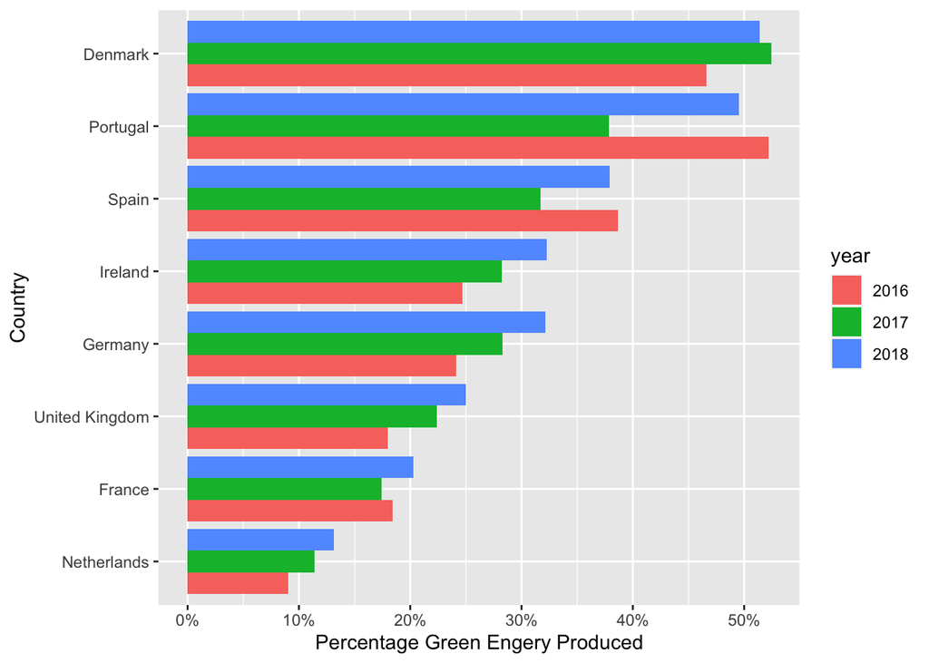

```r
renewable_percentages %>%
  # Filter the data by the list of countries given
  filter(country_name %in% c("Ireland", "United Kingdom", "France", "Spain", "Portugal", "Germany", "Denmark", "Netherlands")) %>%
  # Initial ggplot, note the reorder to sort by highest to lowest
  ggplot(aes(x = reorder(country_name, green_percentage), y = green_percentage, fill = year)) +
  # create a bar chart
  geom_bar(stat = "identity", position='dodge') +
  # add labels
  labs(x = "Country", y = "Percentage Green Engery Produced") +
  # Use percentage formatting for the values (scales library)
  scale_y_continuous(label = percent_format(accuracy = 1)) +
  # Flip the plot so that the country names can be read easily
  coord_flip()
```

### Comparing all countries for a single year

The second plot uses a single year and compares all of the countries.

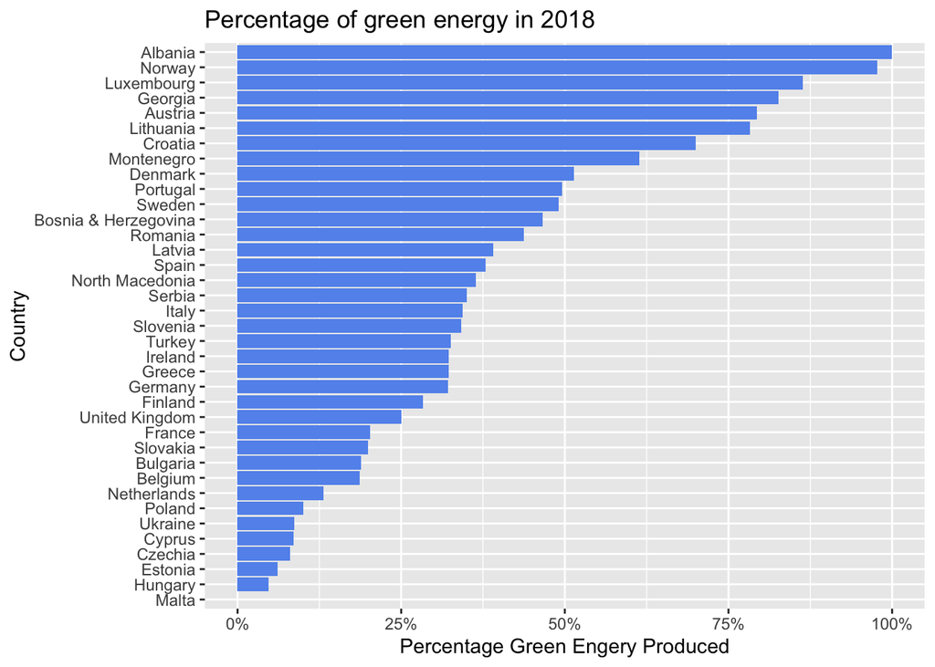

```r
renewable_percentages %>%
  # Filter the data to use 2018
  filter(year == 2018) %>%
  # Initial ggplot
  ggplot(aes(x = reorder(country_name, green_percentage), y = green_percentage)) +
  # create bar chart, fill determines the colour of the bars
  geom_bar(stat = "identity", position='dodge', fill = "cornflowerblue") +
  # add labels
  labs(x = "Country", y = "Percentage Green Engery Produced",
       title = "Percentage of green energy in 2018") +
  # Use percentage formatting for the values (scales library)
  scale_y_continuous(label = percent_format(accuracy = 1)) +
  # Flip the plot so that the country names can be read easily
  coord_flip()
```

## Map Plot

It is possible to use the `maps` package to plot the data on a map of Europe.

Note that some of the country names in the map data do not match the country names in our data. These need to be changed, and there’s no easy way to figure out which countries match other than looking into both datasets.

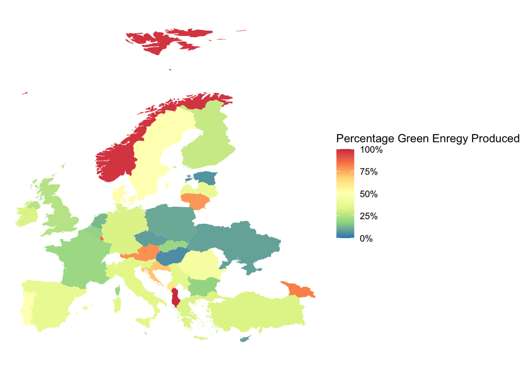

```r
library(maps)

world_map <- map_data("world")

# Change countries names to match
world_map <-
  world_map %>%
  mutate(
    region = case_when(
      region == "UK" ~ "United Kingdom",
      region == "Czech Republic" ~ "Czechia",
      TRUE ~ region
    )
  )


renewable_percentages %>%
  # Filter data to use only 2018
  filter(year == 2018) %>%
  # join the 2 datasets, linking by country name
  left_join(world_map, by = c("country_name" = "region")) %>%
  # Begin ggplot
  ggplot() +
  # add countries and colour using the percentage of renewable energy
  geom_polygon(aes(x = long, y = lat, group = group, fill = green_percentage)) +
  # tidy up the scale/legend used for percentage, formatting with % sign and choosing the colouring
  scale_fill_distiller(palette = "Spectral", label = percent_format()) +
  # Add a title for the scale/legend
  labs(fill = "Percentage Green Enregy Produced") +
  # Change the aspect of the plot
  coord_fixed(1.3) +
  # Remove all other parts of the graph, e.g. box around the plot or lines in background
  theme_void()
```